# MoerserTempo

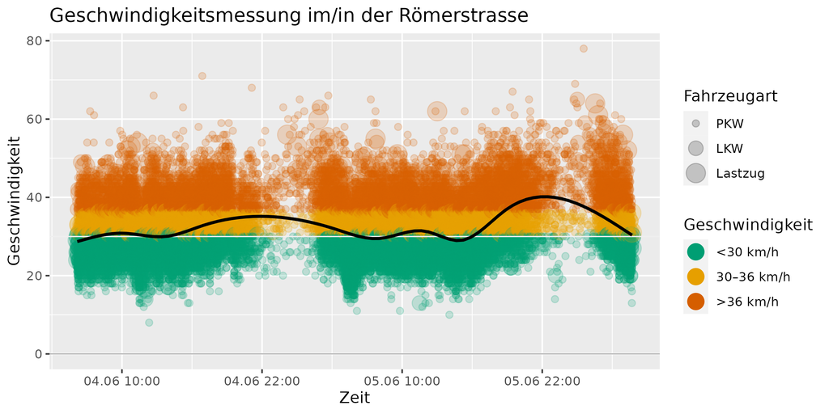

Ich habe den Code vom Originalrepo vom letzten Jahr etwas angepasst, die Ordnerstruktur geändert und die aktuellen Daten von **2021** in dem Ordner `data/verkehrszaehlung_2021` herunter geladen.

Link zum Originalrepo von Stefan Kaufmann und @gruenzeug Juliane Wessalowski: https://github.com/UlmApi/MoerserTempo

## Potentielle Aufgaben für den #oddmo22

- Herausfinden, wie man die im Ordner befindlichen Daten `data/verkehrszaehlung_2021` automatisiert über das CKAN Moers herunter lädt und eventuell ein Tutorial dafür schreiben https://www.offenesdatenportal.de/dataset/verkehrszahlung-in-moers-2021
- Die aktuellen Straßendaten aus `data/verkehrszaehlung_2021` von 2021 im script `verkerhszaehlung_script_2021` mit ggplot visualisieren
- Karte und Webseite im Ordner `/messstellen_2017` mit den aktuellen Straßendaten (es sind einige mehr) updaten
- Bennennung der plots in `verkerhszaehlung_script_2017` und `verkerhszaehlung_script_2021` Funktionen verpacken, statt plot-Titel und plot-Dateien einzeln benennen zu müssen
- `facet_wrap()`-Plots erstellen, um die Daten zu vergleichen
- Verkehrsaufkommen prä-Corona und post-Corona vergleichen

## Tools

- R
- ggpplot2
- tidyverse

## ToDos 2019

- Lesbarkeit bei Straßen mit wenig Verkehrsaufkommen verbessern
- Y-Achsenbeschriftung anpassen

## Lizenz

Dieses Werk ist lizenziert unter einer [Creative Commons Namensnennung 4.0 International Lizenz](http://creativecommons.org/licenses/by/4.0/).